# 90 Miles Inside Chicago: Understanding the City’s Taxi and Ridesharing Customer Segments

## Executive Summary

Segment 1 has the lowest paid fare and tip due to having the shortest trip distance and duration. It is also composed mainly of taxis and is traveling mostly within Near North Side. Segment 2, on the other hand, is situated near South Side with the most frequent route being between Near North Side and the Loop. Coming from Garfield Ridge, which is a small community, is Segment 3 which has the highest ratio of TNPs. And finally, we have Segment 4, which has the highest paid fare and tip with the longest trip distance and duration. However, the travel pattern observed for this segment is quite erratic which made us conclude that customers from this segment are visitors of the city unlike other segments which are composed of locals.

We believe that this study could be used for rate optimization and further developed to explore applications on high variable income businesses, advertising, e-wallet companies, and most importantly, the transportation and urban planning of our very own Metro Manila.

## Introduction

Uber, Lyft, and Sidecar, generally known as ridesharing companies, are recognized in the City of Chicago as Transportation Network Providers (TNP). Ridesharing companies has largely contributed to the growth of the gig economy, giving jobs to 1.5 million Americans [(Miles, 2020)](https://www.foxbusiness.com/economy/gig-workers-facing-extreme-new-competition-in-coronavirus-pandemic-severe-unemployment). Between 2015 and 2018, the annual number of TNP trips in Chicago has grown 271 percent, and the TNP miles traveled with passengers have increased 344 percent [(City of Chicago, 2017)](https://www.chicago.gov/content/dam/city/depts/mayor/Press%20Room/Press%20Releases/2019/October/TNPCongestionReport.pdf?amp=1), thus contributing to the growth of the gig economy. In the face of the pandemic, the gig economy is seen to grow even further. Because of the mass layoffs occurring across the globe, people turned to the gig economy for income. However, the market is now faced with an oversupply of labor, and consistent with the law of supply and demand, this oversupply will cause wages to drop. An impending drop in wages can also be expected for the take-home pay of these TNP drivers.

On the other hand, there is the taxi industry which, on top of the pandemic crisis, is already suffering a decline driven by the rise of the TNP companies. According to the [Certify SpendSmart™ Report](https://www.certify.com/Certify-SpendSmart-Ground-Report-Infographic-Q1-2019.aspx), the market of the taxi industry drops significantly from 49% last Q1 2015 to only 6% as of Q1 2019. Though outweighed by the convenience brought about by TNPs, there are still cases where one would prefer to ride a taxi for availability and security reasons. Therefore, for taxi drivers, it be crucial to optimize operations and revenue in order to survive the shrinking market.

With the rapidly changing industry for both taxis and TNPs, we wish to analyze the various factors that can affect their revenue stream. Aside from fare pricing, what else should drivers look into? For those entering the market as a driver for either industry, what can they expect? Are there certain locations or routes to focus on to maximize income? What is the best time to operate?

This study uses the City of Chicago’s Open Data API on TNP and taxi transactions. Both datasets were limited to all transactions happening in 2019. An exploratory data analysis was conducted to answer the research question.

## Data Description

```python
import numpy as np
import pandas as pd
import matplotlib.pyplot as plt
import seaborn as sns
import geopandas as gpd
from shapely.geometry import Point, Polygon
from IPython.display import HTML
from scipy.stats import kurtosis, skew

%matplotlib inline
```

```python
fn = ('taxi_tnp_weather.csv.gz')
df = pd.read_csv(fn, low_memory=False,
                 parse_dates=['trip_end_timestamp', 'trip_start_timestamp'])
```

```python
df['start_hour'] = df.trip_start_timestamp.dt.hour
df['start_day'] = df.trip_start_timestamp.dt.weekday
df['start_month'] = df.trip_start_timestamp.dt.month

df['end_hour'] = df.trip_end_timestamp.dt.hour
df['end_day'] = df.trip_end_timestamp.dt.weekday
df['end_month'] = df.trip_end_timestamp.dt.month

df.loc[:, 'fare_per_sec'] = df.fare / df.trip_seconds
df.loc[:, 'fare_per_mile'] = df.fare / df.trip_miles
df.loc[:, 'tip_per_sec'] = df.tip / df.trip_seconds
df.loc[:, 'tip_per_mile'] = df.tip / df.trip_miles
```

```python
clusters = pd.read_csv('cluster_labels.csv.gz')
clusters = clusters.loc[:, '4'].rename('cluster').to_frame()
df = pd.merge(df, clusters, left_index=True, right_index=True)
del clusters
```

### TNP data description

The city of Chicago, Illinois has a multitude of publicly available datasets uploaded on their [data portal](https://data.cityofchicago.org/). For this project, we will be using the dataset they have collected on the [Transportation Network Providers](https://data.cityofchicago.org/Transportation/Transportation-Network-Providers-Trips/m6dm-c72p) and the [Taxi Trips](https://data.cityofchicago.org/Transportation/Taxi-Trips/wrvz-psew) operating in the city for the year 2019. Both datasets contain approximately 100 million rows of data pertaining to trip transactions for both transportation type happening in the city. It includes information on a trip’s pick-up and drop-off location, approximated time, fare, tips, distance and duration. See columns used from this dataset below.

**Table 1. Dataset description.**

| Column Name | Description |  |
| --- | --- | --- |
| trip_id | Unique identifier for each trip |  |
| trip_start_timestamp | When the trip started | rounded to the nearest 15 minutes. |
| trip_end_timestamp | When the trip ended | rounded to the nearest 15 minutes. |
| trip_seconds | Time of the trip in seconds. |  |
| trip_miles | Distance of the trip in miles. |  |
| pickup_community_area | The Community Area where the trip began. This column will be blank for locations outside Chicago. |  |
| dropoff_community_area | The Community Area where the trip ended. This column will be blank for locations outside Chicago. |  |
| fare | The fare for the trip, rounded to the nearest \$2.50. |  |
| tip | The tip for the trip, rounded to the nearest $1.00. Cash tips will not be recorded. |  |
| additional_charges | The taxes, fees, and any other charges for the trip. |  |
| trip_total | Sum of fare, tips, and additional charges |  |
| shared_trip_authorized | Whether the customer agreed to a shared trip with another customer, regardless of whether the customer was actually matched for a shared trip. |  |
| trips_pooled | If customers were matched for a shared trip, how many trips, including this one, were pooled. All customer trips from the time the vehicle was empty until it was empty again contribute to this count, … |  |
| pickup_centroid_latitude | The latitude of the center of the pickup census tract or the community area if the census tract has been hidden for privacy. This column often will be blank for locations outside Chicago. |  |
| pickup_centroid_longitude | The longitude of the center of the pickup census tract or the community area if the census tract has been hidden for privacy. This column often will be blank for locations outside Chicago. |  |
| dropoff_centroid_latitude | The latitude of the center of the dropoff census tract or the community area if the census tract has been hidden for privacy. This column often will be blank for locations outside Chicago. |  |
| dropoff_centroid_longitude | The longitude of the center of the dropoff census tract or the community area if the census tract has been hidden for privacy. This column often will be blank for locations outside Chicago. |  |
| Type | The type of an event; examples are rain and snow |  |
| Severity | The severity of an event, wherever applicable. |  |
| payment_is_cashless | Transaction type that occurred. The values are cash, cashless, or unknown transactions |  |
| TransportType | The kind of transportation service used; values are `taxi` or `tnp` |  |

To understand further the merged dataset, found in Table 2 is summary statistics of interesting features alongside their distribution plots. Table 2 shows that the average fare is about \$12, with 4.42 miles as the average distance and an average trip duration of about 15 mins. This implies that the average fare per mile is about \\$2.80 and an average fare per minute of \$0.82 for both taxi and TNP.

```python
desc = df.drop(columns=['company', 'trip_id', 'Type', 'Severity',
                        'trip_start_timestamp', 'trip_end_timestamp',
                        'payment_is_cashless', 'TransportType',
                        'dropoff_centroid_latitude',
                        'dropoff_centroid_longitude',
                        'dropoff_community_area', 'pickup_centroid_latitude',
                        'pickup_centroid_longitude', 'pickup_community_area',
                        'start_hour', 'start_day', 'start_month', 'end_hour',
                        'end_day', 'end_month', 'cluster', 'payment_type',
                        'fare_per_sec', 'fare_per_mile', 'tip_per_sec',
                        'tip_per_mile'])

display(HTML("<b>Table 2. Descriptive statistics on main trip features.</b>"))
desc.describe().T
```

**Table 2. Descriptive statistics on main trip features.**

|  | count | mean | std | min | 25% | 50% | 75% | max |
| --- | --- | --- | --- | --- | --- | --- | --- | --- |
| fare | 480608.0 | 12.371886 | 23.673456 | 0.010000 | 5.750000 | 8.00 | 12.500000 | 8001.45 |
| tip | 480608.0 | 1.209979 | 2.408794 | 0.000000 | 0.000000 | 0.00 | 2.000000 | 100.00 |
| trip_miles | 480608.0 | 4.421506 | 5.170428 | 0.000084 | 1.114041 | 2.25 | 5.398353 | 210.20 |
| trip_seconds | 480608.0 | 953.718556 | 1091.781399 | 1.000000 | 439.000000 | 716.00 | 1186.000000 | 81473.00 |
| trip_total | 480608.0 | 15.464032 | 24.855346 | 0.010000 | 7.550000 | 10.25 | 15.750000 | 8002.05 |
| additional_charges | 480608.0 | 1.804088 | 2.342255 | 0.000000 | 0.000000 | 2.55 | 2.550000 | 757.50 |

To understand further, we can look at the distribution plots of the relevant features and measure their skewness and kurtosis, shown in Figure 1. The values of the kurtosis across all features are quite high, as shown in Table 3. This means that there is a high chance for extreme occurrences to happen. This may be attributed to the variation in customer behavior and traffic behavior at certain times. Interestingly, `tip` and `trip_miles` have small values for kurtosis. The reason may be attributed to the relatively consistent passenger routes and certain cultural standards for tipping behavior when compared to the other features.

**Table 3. Skewness and kurtosis of trip features.**

|  | Skewness | Kurtosis |
| --- | --- | --- |
| fare | 170.264976 | 42576.110968 |
| tip | 3.340428 | 27.719427 |
| trip_miles | 2.288047 | 15.360231 |
| trip_seconds | 28.202981 | 1578.871693 |
| trip_total | 147.119069 | 34976.678801 |
| additional_charges | 87.273804 | 25511.666933 |

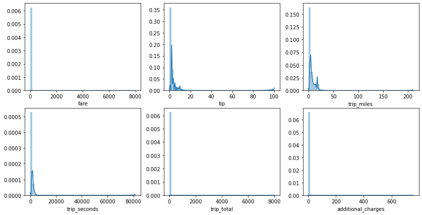

```python
fig, ax = plt.subplots(2, 3, figsize=(14, 7))  # edit if needed
sns.distplot(df['fare'], ax=ax[0][0])
sns.distplot(df['tip'], ax=ax[0][1])
sns.distplot(df['trip_miles'], ax=ax[0][2])
sns.distplot(df['trip_seconds'], ax=ax[1][0])
sns.distplot(df['trip_total'], ax=ax[1][1])
sns.distplot(df['additional_charges'], ax=ax[1][2])

# get the skewness and kurtosis of fare and tip
tails = [[skew(df['fare']), kurtosis(df['fare'])],
         [skew(df['tip']), kurtosis(df['tip'])],
         [skew(df['trip_miles']), kurtosis(df['trip_miles'])],
         [skew(df['trip_seconds']), kurtosis(df['trip_seconds'])],
         [skew(df['trip_total']), kurtosis(df['trip_total'])],
         [skew(df['additional_charges']), kurtosis(df['additional_charges'])]]

# display results
display(HTML('<b>Table 3. Skewness and kurtosis of trip features.</b>'))
display(pd.DataFrame(tails, columns=['Skewness', 'Kurtosis'],
                     index=desc.columns))

# for demarcating the dataframe and the plots
display(HTML('<b>Figure 1. Distribution plots of fare and tip.</b>'))
```

## Methodology

For this study, we followed the following steps to answer the problem statement:

1. Scraping. Data was first scraped from the Chicago data portal for both the taxi and TNP datasets. Because of the huge amount of data for each dataset and the limitation by the endpoints of 5000 records per request, they were iteratively gathered from the API endpoints and written into a database.
2. Clean-up and Sampling. The datasets are too large to be processed so the datasets were randomly sampled to a more manageable size. During the process, some clean-up steps were done and imputation of null values. The datasets were also evenly sampled later for equal parts taxi and TNP datapoints.
3. Dimentionality Reduction. Using PCA, the number of features used for clustering were reduced.
4. Clustering. We applied $k$-medians clustering on the reduced dimensions and chose an appropriate number of clusters based on inertia and the calinski-harabasz score.
5. Exploratory Data Analysis. Each of the clusters were then studied to bring out insights on the segments and behavior of the passengers.

### Scraping

#### Building the taxi dataset

1. Using the requests library, we requested data from https://data.cityofchicago.org/resource/wrvz-psew.json filtered using `trip_start_timestamp`
2. The script was run in multiple parallel processes to retrieve data faster
3. The query ran on an interval basis every 5,000 datapoints until all 2019 taxi data were retrieved. Data was appended in an sqlite database every iteration for persistence
4. The taxi data was deduped based on its trip_id.

#### Building the TNP dataset

1. Using the requests library, we requested data from https://data.cityofchicago.org/resource/m6dm-c72p.json filtered using `trip_start_timestamp`
2. The script was run in multiple parallel processes to retrieve data faster. Each parallel run aimed to complete a month’s worth of TNP trip data.
3. Each iteration of the request ran on an interval of 5,000 datapoints until all the months' worth of data is retrieved. Data is appended to an SQLite database every iteration for persistence.

*Note*: The code for this section is detailed in `tnp-taxi-scraper.ipynb`.

### Clean-up and Sampling

After scraping the dataset, we sampled 2% worth of data from each of the datasets compiled. This resulted to approximately 310,000 datapoints for the taxi dataset and 2M datapoints for the TNP dataset. We cleaned the datasets by removing erroneous records like trips with no `fare`, `trip_total`, distance (`trip_miles`) or duration (`trip_seconds`). We also removed trips that went outside the city limits, which were datapoints with either no pickup/dropoff `community_area` or `longitude`/`latitude`. This yielded approximately 240,000 datapoints for the taxi dataset and 1.8M datapoints for TNP.

Some datapoints in the taxi dataset had `null` values for `tolls` which were imputed with 0 instead of the mean since not all trips would have passed through tolls. We also remapped the payment type to certain categories instead of what existed in the dataset. For example, there were multiple payment types that pertained to prepaid card transactions while there were some transactions labeled “dispute” which we agreed to categorize as unknown types of payment. We also mapped whether the transaction was cashless or not.

For the TNP datapoints, we added a `payment_type` column of `mobile` since TNPs only transacted via their mobile application and since no other determining factor for the TNP transactions could be extracted from the information provided. Naturally, all TNP transactions were marked as cashless.

Since we wanted an equal number of trips between taxi and TNP trips, we randomly sampled 240,304 datapoints from the TNP dataset. The two columns (`tolls` and `extras`) from the taxi dataset did not exist in the TNP dataset as separate columns but as an aggregate column `additional_charges`. To merge the datasets together, we added the `tolls` and `extras` column into an `additional_charges` column and dropped the prior columns. We also added `TransportType` label to distinguish taxi and TNP trips. From here we were able to merge the two datasets into one file.

*Note*: The code for this section is detailed in (1) `sampling-files.ipynb` (for the initial sampling), and then (2) `data-processing-sampling.ipynb` (for the cleaning and evenly sampling the dataset).

### Dimensionality Reduction

We decided to use the following features to cluster the complete dataset to achieve the customer segments:

| Clustering Features |  |
| --- | --- |
| dropoff_centroid_latitude | dropoff_centroid_longitude |
| pickup_centroid_latitude | pickup_centroid_longitude |
| fare | tip |
| trip_miles | trip_seconds |
| trip_total | additional_charges |
| payment_type |  |

Using PCA as the dimensionality reduction technique and setting the threshold to 95%, we were left with 11 PCs to be used for the clustering.

*Note*: The code for this section is detailed in `dimensionality-reduction.ipynb`.

```
Number of PCs for above 95% Explained Variance: 11
```

**Figure 2. Variance Explained for PCA.**

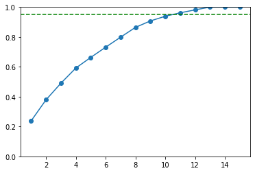

```python
exp_var = np.load('exp_var.npy')
print('Number of PCs for above 95% Explained Variance:',
      np.size(exp_var) - np.sum(exp_var.cumsum() > 0.95) + 1)
plt.plot(range(1, len(exp_var)+1), exp_var.cumsum(), 'o-')
plt.gca().axhline(0.95, c='g', ls='--')
plt.ylim([0, 1])
display(HTML('<b>Figure 2. Variance Explained for PCA.</b>'))
plt.show();
```

### Clustering

For the clustering technique, we used k-medians since a good portion of the dataset contained outliers. We used internal validation metrics to determine the best number of clusters $k$. Because of the size of the dataset, we decided to use inertia and Calinski-Harabasz (CH score) as the primary metrics to use to determine the optimal number of clusters.

**Figure 3. K-medians Internal Validation Metrics.**

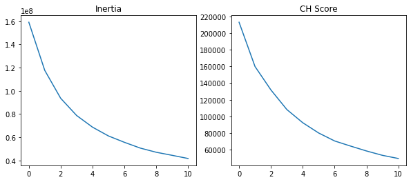

```python
validation = pd.read_csv('validation.csv.gz', skiprows=1,
                         names=['index', 'inertias', 'chs'])
display(HTML('<b>Figure 3. K-medians Internal Validation Metrics.</b>'))
fig, ax = plt.subplots(ncols=2, figsize=(10, 4))
validation.inertias.plot(ax=ax[0])
validation.chs.plot(ax=ax[1])
ax[0].set_title('Inertia')
ax[1].set_title('CH Score');
```

Based on the graphs of inertia, there are two noticeable areas where an elbow can be determined – at $k = 4$ and $k = 6$. However, we’ve chosen the number of clusters to be 4 to maintain a high enough CH score. More so, based on an initial EDA of the resulting clusters, we’ve observed that the resulting 4 clusters are more interpretable.

*Note*: The code for this section is detailed in the `clustering.ipynb`

## Results and Discussion

### Insight #1: The clustering created customer segments based on trip duration and distance.

Found in Figure 4 are the mean trip miles, seconds, fare, tip and additional charges per segment.

**Figure 4. Mean trip features per segment.**

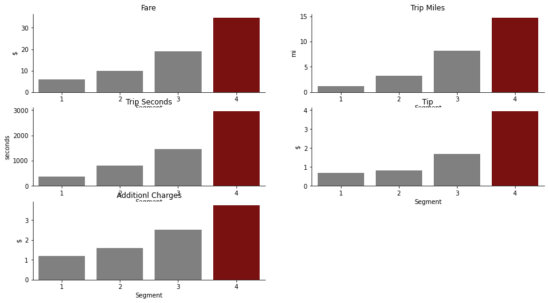

```python
display(HTML('<b>Figure 4. Mean trip features per segment.</b>'))

fig, axes = plt.subplots(ncols=2, nrows=3, figsize=(15, 8))

avefare = pd.DataFrame(df.groupby(['cluster'])['fare'].agg('mean'))
avemiles = pd.DataFrame(df.groupby(['cluster'])['trip_miles'].agg('mean'))
aveseconds = pd.DataFrame(df.groupby(['cluster'])['trip_seconds'].agg('mean'))
avetip = pd.DataFrame(df.groupby(['cluster'])['tip'].agg('mean'))
aveac = pd.DataFrame(df.groupby(['cluster'])['additional_charges']
                         .agg('mean'))
summgraphs = [avefare, avemiles, aveseconds, avetip, aveac]
gb_cols = ['fare', 'trip_miles', 'trip_seconds', 'tip', 'additional_charges']
titles = ['Fare', 'Trip Miles', 'Trip Seconds', 'Tip', 'Additionl Charges']
ylabs = ["$", "mi", "seconds", "$", "$"]
for i, j, k, l, ax in zip(summgraphs, gb_cols, titles, ylabs, axes.flatten()):
    clrs = ['grey' if (x < max(i[j])) else 'darkred' for x in i[j]]
    sns.barplot(i.index, i[j], palette=clrs, ax=ax)
    ax.set_title(k)
    ax.set_xlabel("Segment")
    ax.set_ylabel(l)
    sns.despine(top=True, right=True)
    ax.set(xticklabels=['1', '2', '3', '4'])

axes.flatten()[-1].remove()
plt.show()
```

Found in Figure 5 are proportion of transactions split between taxis and ridesharing.

**Figure 5. Share between taxi and ridesharing transactions per segment.***

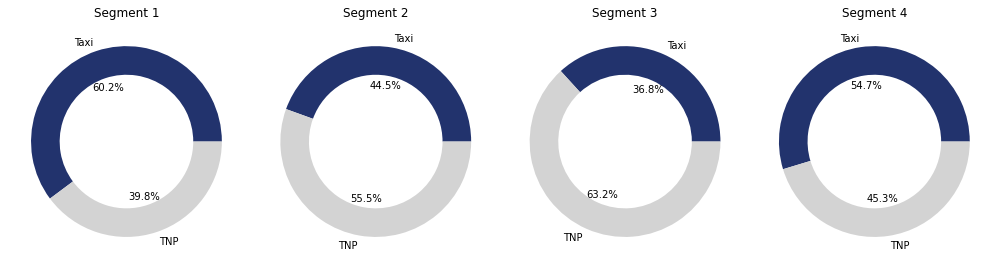

```python
display(HTML('<b>Figure 5. Share between taxi and ridesharing transactions per segment.*</b>'))
fig, axes = plt.subplots(1,4, figsize=(14,5))
for ax, cl in zip(axes, range(4)):
    dat = df[df['cluster'] == cl].groupby('TransportType').size()
    ax.pie(dat, wedgeprops=dict(width=.3), labels=['Taxi', 'TNP'],
           colors=['#22336D', 'lightgray'], autopct='%1.1f%%')
    ax.set(ylabel='', title=f'Segment {cl + 1}',
           aspect='equal')
plt.tight_layout()
```

### Insight #3: From a customer perspective, ridesharing transactions are more cost efficient.

Found in Figure 6 are the fare per mile and fare per second across the segments and transport types.

**Figure 6. Fare per mile and per minute across segments and transportation types.***

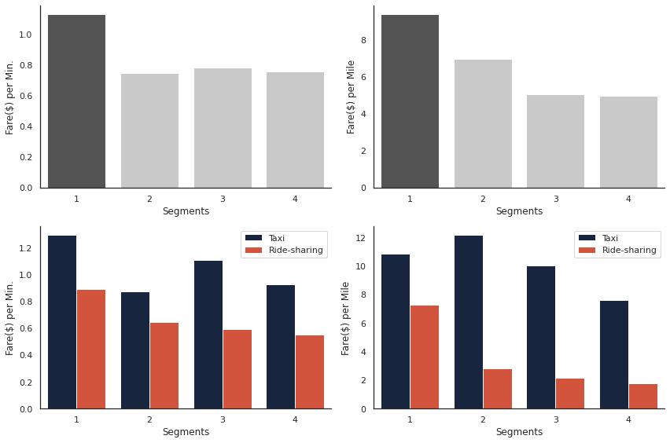

```python
display(HTML('<b>Figure 6. Fare per mile and per minute across segments and transportation types.*</b>'))
sns.set(font_scale=1)
sns.set_style('white')
fig, ax = plt.subplots(ncols=2, nrows=2, figsize=(12, 8))

sns.barplot(x='cluster', y='fare_per_sec',
            data=(df.groupby('cluster').mean()[
                  ['fare_per_sec']]*60).reset_index(),
            ax=ax[0, 0], ci=None, palette=['#545454', '#C9C9C9',
                                           '#C9C9C9', '#C9C9C9'])
ax[0, 0].set_xticklabels([f'{i+1}' for i in range(4)])
ax[0, 0].set_ylabel('Fare($) per Min.')
ax[0, 0].set_xlabel('Segments')

sns.barplot(x='cluster', y='fare_per_mile',
            data=(df.groupby('cluster')
                  .mean()[['fare_per_mile']]).reset_index(),
            ax=ax[0, 1], ci=None,
            palette=['#545454', '#C9C9C9', '#C9C9C9', '#C9C9C9'])
ax[0, 1].set_xticklabels([f'{i+1}' for i in range(4)])
ax[0, 1].set_ylabel('Fare($) per Mile')
ax[0, 1].set_xlabel('Segments')


cluster_transport_group = (df.groupby(['cluster', 'TransportType'])
                           .mean()[['fare_per_sec', 'fare_per_mile']])

df_to_plot = (cluster_transport_group.reset_index()
              .assign(fare_per_sec=lambda x: x['fare_per_sec']*60)
              .melt(value_vars=['fare_per_sec', 'fare_per_mile'],
                    id_vars=['TransportType', 'cluster']))
sns.barplot(x='cluster', y='value', hue='TransportType',
            data=df_to_plot[df_to_plot['variable'] == 'fare_per_sec'],
            ax=ax[1, 0], ci=None, palette=['#112346', '#EB4323'])
ax[1, 0].set_xticklabels([f'{i+1}' for i in range(4)])
ax[1, 0].set_ylabel('Fare($) per Min.')
ax[1, 0].set_xlabel('Segments')
ax[1, 0].legend(['Taxi', 'Ride-sharing'])
sns.barplot(x='cluster', y='value', hue='TransportType',
            data=df_to_plot[df_to_plot['variable'] == 'fare_per_mile'],
            ax=ax[1, 1], ci=None, palette=['#112346', '#EB4323'])
ax[1, 1].set_xticklabels([f'{i+1}' for i in range(4)])
ax[1, 1].set_ylabel('Fare($) per Mile')
ax[1, 1].set_xlabel('Segments')
ax[1, 1].legend(['Taxi', 'Ride-sharing'])
sns.despine()
plt.xticks(rotation=0)
plt.tight_layout()
plt.show()
```

However, if we were to split it by the transportation service (as seen on bottom row graphs), we find that taxis are generally more cost inefficient whether we consider fare per mile or minute. If we look at the fare per mile and per minute graphs of taxi transactions, we find that taxi transactions are consistently cost inefficient. If we look closely at both fare per mile and per minute graphs of ridesharing transactions, we notice a gradual descent from Segment 1 to 4, with Segment 4 ridesharing customers having the most cost-efficient transactions. Segment 1 ridesharing transactions are more cost inefficient, compared to other segments, and this may be because of the short trip distances.

In general, the stark difference of cost efficiency between the two transport types can be attributed to the difference in fare computation. Ridesharing companies, such as Uber, follow a dynamic pricing scheme, while taxi companies follow a set fare matrix passed by the City of Chicago’s Business Affairs and Consumer Protection [(City of Chicago, n.d.)](https://www.chicago.gov/city/en/depts/bacp/supp_info/2012_passenger_information.html).

### Insight #4: Travel patterns of Segment 4 transactions followed an erratic travel pattern.

Found in Figure 7 are the proportion of trips taken by a customer segment within a given time frame to all trips taken by a customer segment, to normalize for the number of trips taken by each of the customer segments.

Figure 7. Proportion of trips taken by a customer segment within a given month, day, or hour to the total number of trips  
taken by a customer segment.

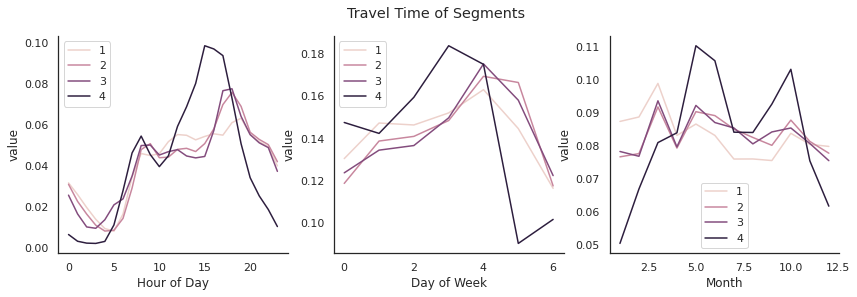

```python
display(HTML('<b>Figure 7. Proportion of trips taken by a customer segment within a given month, day, or hour to the total number of trips <br> taken by a customer segment.</b>'))
fig, axes = plt.subplots(ncols=3, figsize=(14, 4))
labels = ['Hour of Day', 'Day of Week', 'Month']
cols = ['start_hour', 'start_day', 'start_month']
for t, l, ax in zip(cols, labels, axes):
    hour_of_day = (df.pivot_table(index='cluster', columns=t, aggfunc='size'))
    hour_of_day = hour_of_day.divide(hour_of_day.sum(axis=1), axis=0)
    sns.lineplot(x=t, y='value', hue='cluster',
                 data=hour_of_day.T.reset_index().melt(id_vars=[t]),
                 ax=ax)
    ax.set_xlabel(l)
    ax.legend([1,2,3,4])
plt.suptitle("Travel Time of Segments")
sns.despine()
```

Segments 1, 2, and 3, all usually follow a set pattern of travel times. What jumps out is Segment 4's travel pattern, characterized by the erratic spikes and drops, regardless whether monthly, daily, or hourly graphs are considered. We think this is because Segment 4 transactions are made by visitors to Chicago while the rest of the segments are transactions made by locals. Given that the O’Hare International Airport is a major airport, airport arrivals to Chicago generally do not follow a set time pattern. This finding can be further supported by Figures 8 and 9.

**Figure 8. Heat map of customer segments’ pickup locations.**

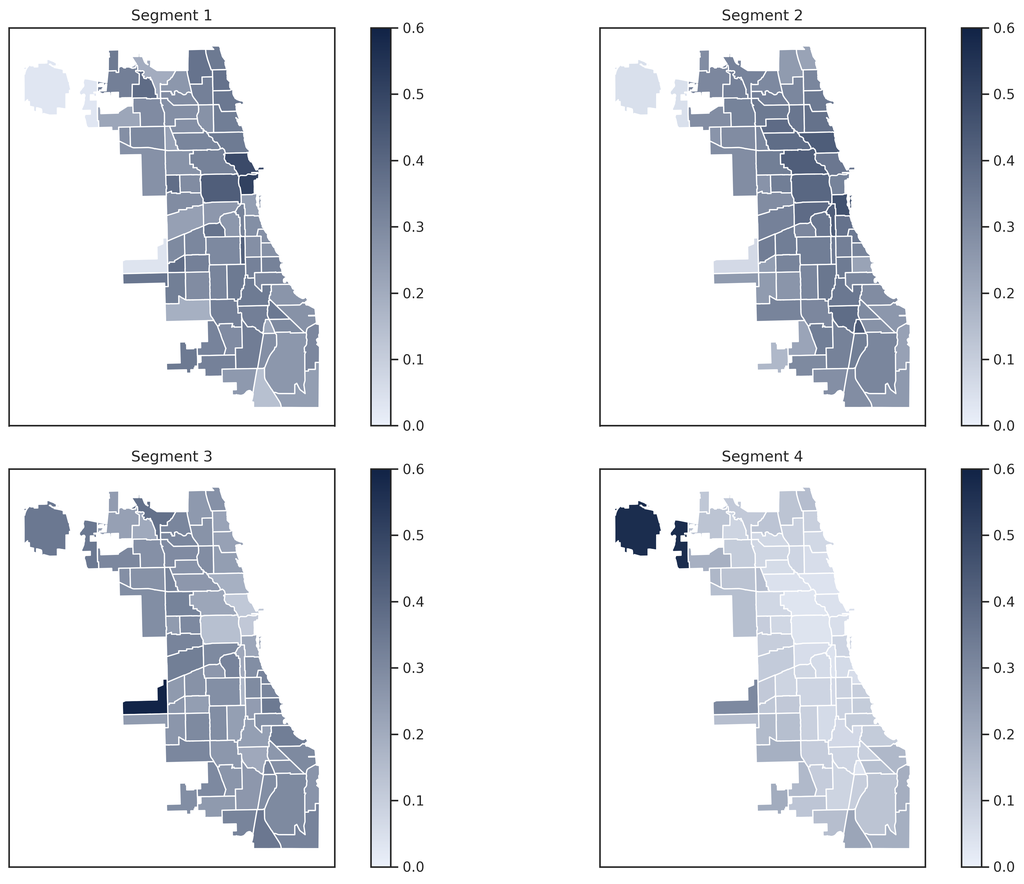

```python
# Community Area Heatmap

display(HTML("<b>Figure 8. Heat map of customer segments’ pickup locations.</b>"))
comm_cluster = df.pivot_table(index='pickup_community_area',
                              columns='cluster', aggfunc='size')
comm_cluster = comm_cluster.divide(comm_cluster.sum(axis=1), axis=0)
comm_cluster.columns = ['pickup_0', 'pickup_1', 'pickup_2', 'pickup_3']

street_map = gpd.read_file('geo/geo_export_11684996-2f89-4e5b-b7a9-'
                           'e29a7489d238.shx')
street_map.area_num_1 = street_map.area_num_1.astype(float)
street_map = pd.merge(street_map, comm_cluster, left_on='area_num_1',
                      right_index=True)
street_map['coords'] = (street_map['geometry']
                            .apply(lambda x: x.representative_point()
                                              .coords[:]))
street_map['coords'] = [coords[0] for coords in street_map['coords']]

fig, axes = plt.subplots(ncols=2, nrows=2, figsize=(15, 10), dpi=300)

for i, ax, h in zip(range(4), axes.flatten(),
                    ['#112346', '#112346', '#112346', '#112346']):
    street_map.plot(ax=ax, column=f'pickup_{i}',
                    cmap=sns.light_palette(h, as_cmap=True),
                    legend=True, vmin=0, vmax=0.6)
    ax.set_yticklabels([""])
    ax.set_xticklabels([""])
    ax.set_title(f"Segment {i+1}")

plt.tight_layout()
# plt.suptitle("Heat map of customer segments’ pickup locations")
plt.show()
```

We highlight 4 key areas the customer segments usually come from: Segment 1 can usually come from either 1) Near North Side, composed of several upscale neighborhoods, or 2) The Loop, the central business district. Segment 2 usually originates from Near South Side, another upscale residential area near the central business district. Segment 3 usually comes from Garfield Ridge, small community but home to the Midway Airport. Segment 4 mostly comes from O'Hare, or the O'Hare International Airport.

Found in Figure 9 are the maps of Chicago, wherein the highlighted areas refer to community areas considered as the top route. Route from Point A to B is considered unique from Point B to A.

**Figure 9. Map of Chicago, highlighted with the top route of each segment.**

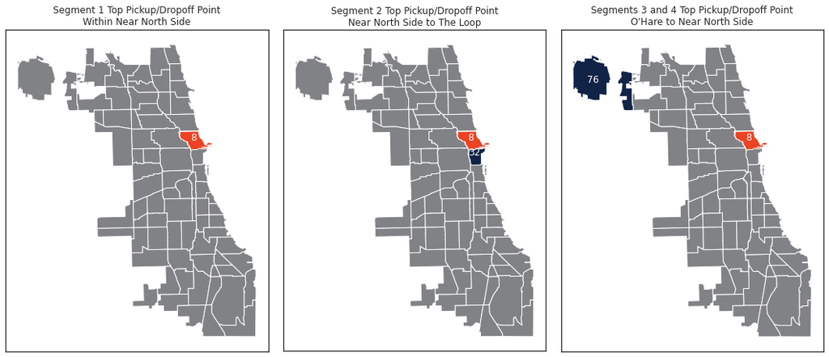

```python
display(HTML("<b>Figure 9. Map of Chicago, highlighted with the top route of each segment.</b>"))

fig, ax = plt.subplots(ncols=3, figsize=(15, 15))

street_map.plot(ax=ax[0], color='#818286')
street_map[street_map.area_numbe == '8'].plot(
    ax=ax[0], color='#EB4323', label='sdfsdf')
ax[0].annotate(s=8, xy=street_map[street_map.area_numbe == '8']['coords'].to_numpy()[0],

               horizontalalignment='center', color='white')
ax[0].set_title('Segment 1 Top Pickup/Dropoff Point\nWithin Near North Side')


street_map.plot(ax=ax[1], color='#818286')
street_map[street_map.area_numbe == '8'].plot(ax=ax[1], color='#EB4323')
street_map[street_map.area_numbe == '32'].plot(ax=ax[1], color='#112346')
ax[1].annotate(s=8, xy=street_map[street_map.area_numbe == '8']['coords'].to_numpy()[0],
               horizontalalignment='center', color='white')
ax[1].annotate(s=32, xy=street_map[street_map.area_numbe == '32']['coords'].to_numpy()[0],
               horizontalalignment='center', color='white')
ax[1].set_title('Segment 2 Top Pickup/Dropoff Point\nNear North Side to The Loop')

street_map.plot(ax=ax[2], color='#818286')
street_map[street_map.area_numbe == '8'].plot(ax=ax[2], color='#EB4323')
street_map[street_map.area_numbe == '76'].plot(ax=ax[2], color='#112346')
ax[2].annotate(s=8, xy=street_map[street_map.area_numbe == '8']['coords'].to_numpy()[0],
               horizontalalignment='center', color='white')
ax[2].annotate(s=76, xy=street_map[street_map.area_numbe == '76']['coords'].to_numpy()[0],
               horizontalalignment='center', color='white')
ax[2].set_title(
    'Segments 3 and 4 Top Pickup/Dropoff Point\nO\'Hare to Near North Side')

for i in range(3):
    ax[i].set_xticklabels([])
    ax[i].set_yticklabels([])

plt.tight_layout()
```

### Summary

Presented in Table 4 is a summary of our findings.

|  | Segment 1 | Segment 2 | Segment 3 | Segment 4 |
| --- | --- | --- | --- | --- |
| Fare | Lowest amount paid, shortest duration and distance | 3rd place in highest amount paid, 3rd place in trip duration and distance | 2nd place in highest amount paid, 2nd place in trip duration and distance | Highest amount paid, longest duration and distance |
| Transport Type | Taxi |  | Ridesharing |  |
| Time |  |  |  | Erratic |
| Frequent pickup community area | Near North Side / The Loop | Near South Side | Garfield Ridge | O’Hare |
| Route | Within Near North Side | Near North Side to The Loop | O’Hare to Near North Side | O’Hare to Near North Side |

We find that the clustering brough about customer segments with varying travel behaviors, in terms of the basic trip features, their travel patterns, and routes.

## Conclusion and Recommendations

The main segments were created based on the trip’s main features which are duration and distance. Each succeeding segment followed an incremental behavior based on the previous segment’s trip features. Although lower segments indicate lower fares, looking at the ratio would show that taxis are are priced higher due to their own fare matrix, unlike its ridesharing counterparts that follows a dynamic pricing scheme. Segment 4 shows an erratic behavior compared to the other segments and with O’Hare being included in this segment’s top routes, we think that Segment 4 is composed of transactions made by Chicago visitors. It was found that drivers would most likely have passengers in the northern area of Chicago, because of the high population density.

Here are our group’s recommendations to improve this study and to explore further use cases:

- The behavior of each customer segment can be used to optimize the fares for each segment.
- This study could be re-applied in other high variable income businesses like restaurants or resorts.
- This study could be used for traditional and non-traditional advertising. Advertisers could choose specific locations to target a specific customer segment (e.g. billboards, posters). Non-traditional advertising could also be done based on routes. (e.g. advertisers could display digital ads inside taxis that frequent O’Hare targeting Segment 4).
- We could explore more into which customer segments to target to expand the reach of cashless payment types like e-wallets, a commonly used payment method in this era.
- The original intent of our team was to use this study in the Philippine setting to help our urban planners and ultimately help in nation building. It would be interesting to see how we fare considering the traffic situation and other regulations

## References

https://en.wikipedia.org/wiki/O%27Hare,_Chicago

https://en.wikipedia.org/wiki/Near_North_Side,_Chicago

https://en.wikipedia.org/wiki/Community_areas_in_Chicago

Certify. (2019). Certify SpendSmart™ Ground Transportation Report Q1 2019. Retrieved on August 22, 2020 from https://www.certify.com/Certify-SpendSmart-Ground-Report-Infographic-Q1-2019.aspx

City of Chicago. (2018). City of Chicago Congestion Report on Transportation Network Providers. Retrieved on August 1, 2020 from https://www.chicago.gov/content/dam/city/depts/mayor/Press%20Room/Press%20Releases/2019/October/TNPCongestionReport.pdf?amp=1

City of Chicago. (2017). Transportation Network Providers Rules. Retrieved from https://www.chicago.gov/content/dam/city/depts/bacp/rulesandregs/TNPRulesAmendedeffJan12017.pdf

City of Chicago (n.d.). City of Chicago Taxicab Fare Rates and Information. Retrieved on August 22, 2020 from https://www.chicago.gov/city/en/depts/bacp/supp_info/2012_passenger_information.html

Miles, F. (2020, July 6) Gig workers facing extreme new competition in coronavirus pandemic, severe unemployment. Fox Business. Retrieved on August 22, 2020 from https://www.foxbusiness.com/economy/gig-workers-facing-extreme-new-competition-in-coronavirus-pandemic-severe-unemployment